# Ejercicios del Capítulo 3

Christian Limbert Paredes Aguilera

30/12/2021

```r
#librerias
library(ggplot2)
```

# 3.1

### a)

```r
X <- c(0,1,2,3,4,5,6,7)
fp <- c()
for (x in 0:7) {
  fp <- c(fp, exp(-3)*3^x / factorial(x))
}
df <- data.frame(X,fp)
```

### b)

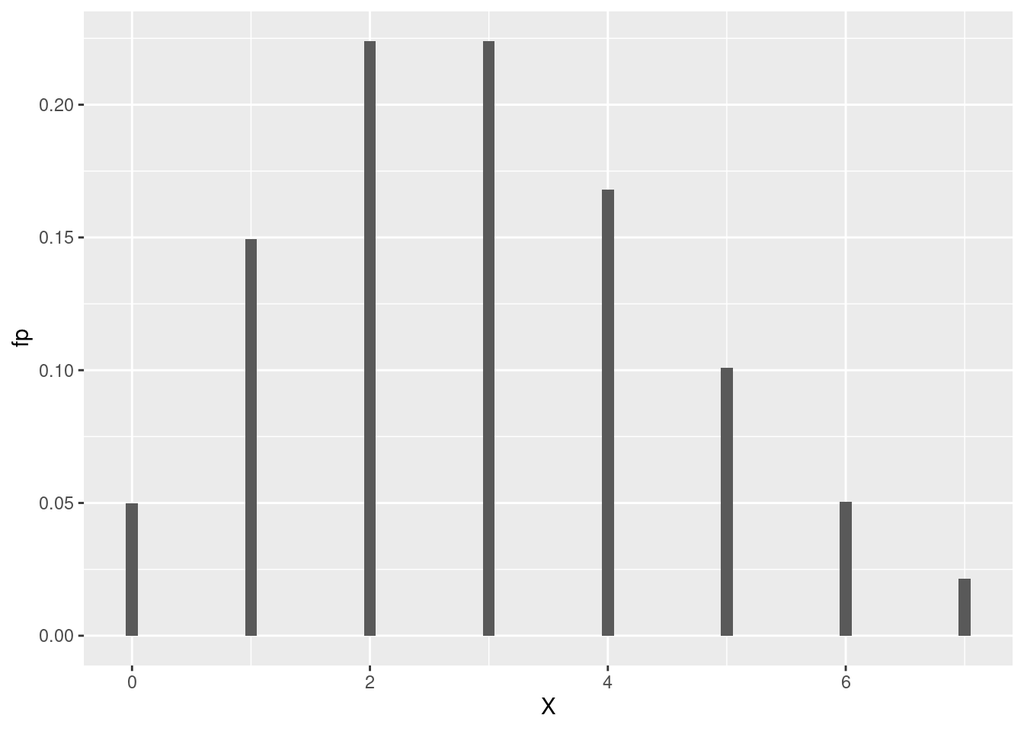

```r
ggplot(data = df, mapping = aes(X,fp)) +
  geom_col(width = 0.1)
```

### c)

```r
fda <- c()
sum <- 0
for (x in 0:7) {
  sum <- sum + (exp(-3)*3^x / factorial(x))
  fda <- c(fda,sum)
}
df <- data.frame(X,fp,fda)
print(fda)
```

```
## [1] 0.04978707 0.19914827 0.42319008 0.64723189 0.81526324 0.91608206 0.96649146
## [8] 0.98809550
```

### d)

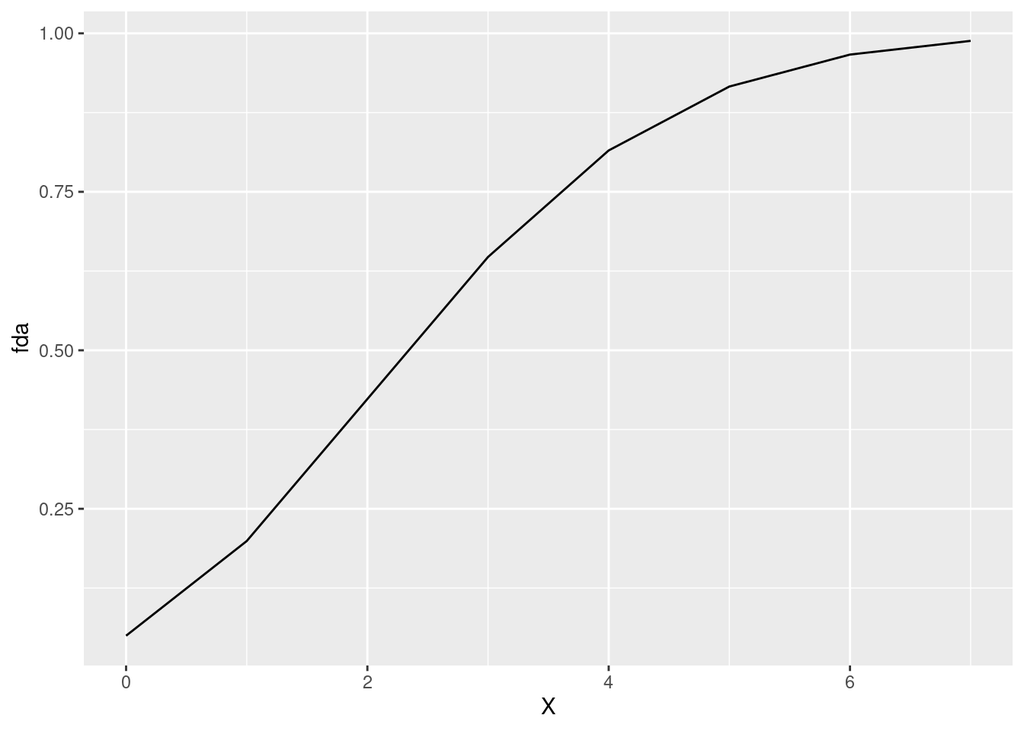

```r
ggplot(data = df, mapping = aes(X,fda)) +
  geom_line(width = 2)
```

# 3.2.

Por definición 3.4, sea
$$k+\dfrac{k}{2}+\dfrac{k}{3}+\dfrac{k}{4}=1 \quad \Longrightarrow \quad k=\dfrac{12}{25}$$

entonces la función de probabilidad de una variable aleatoria discreta $X$ estará dada por:

$$p(x) = \left\{\begin{array}{rcl}
\dfrac{12}{25}&si&x=1\\\\
\dfrac{6}{25}&si&x=2\\\\
\dfrac{4}{25}&si&x=3\\\\
\dfrac{3}{25}&si&x=4\\
\end{array}\right.$$

# 3.3.

### a)

Según la definición 3.6 se tiene,
$$\int_{-x}^x kx^2\; dx = \int_{-1}^1 kx^2\; dx = 1 \quad \Longrightarrow \quad k=\dfrac{3}{2}$$

```r
integrate(function(x) 3/2*x^2, lower = -1, upper = 1)
```

```
## 1 with absolute error < 1.1e-14
```

### b)

$$P(X\leq x) = \int_{-\infty}^x f(t)\; dt = \int_{-\infty}^{-1} 0\; dt + \int_{-1}^x \dfrac{3}{2}t^2\; dt = \dfrac{3}{2} \cdot \dfrac{x^3+1}{3} =\dfrac{x^3+1}{2}$$

```r
funcdist <- function(x) (x^3+1)/2
```

$$P(X\leq x) = \left\{\begin{array}{rcl}
\dfrac{x^3+1}{2}&si&x>0\\\\
0&si&\mbox{Para cualquier otro valor}\\\\
\end{array}\right.$$

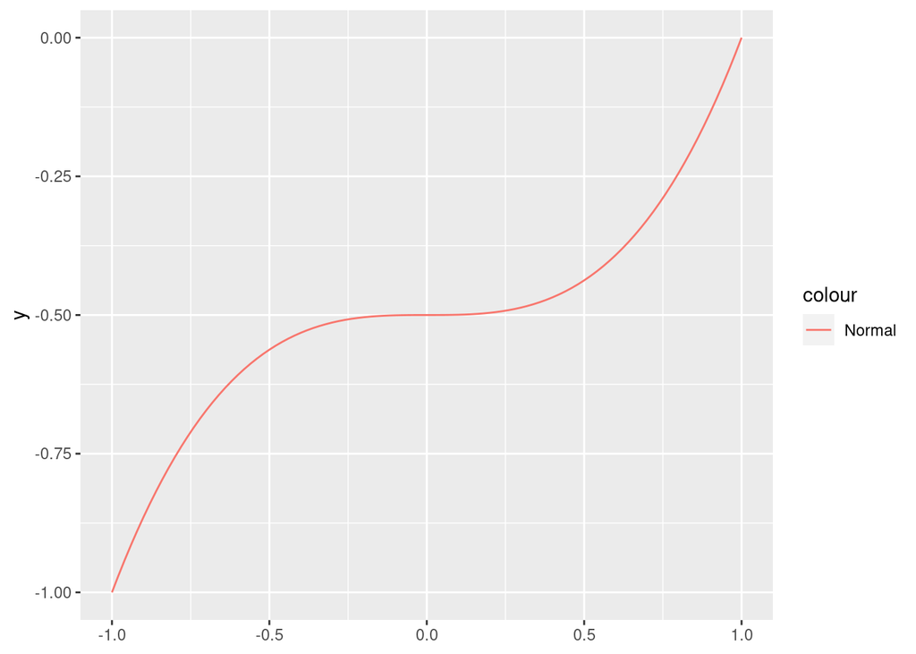

```r
ggplot() +
   xlim(-1, 1) +
   geom_function(
     aes(color = "Normal"),
     fun =~ (.x^3-1)/2
     )
```

### c)

$$P(X\geq 1/2) = 1 - P(X\leq 1/2) = 1 - \dfrac{x^3+1}{2} = 1 - \dfrac{\left(1/2\right)^3+1}{2} =1- \dfrac{9/8}{2} = \dfrac{7}{16}$$

```r
1-funcdist(1/2)
```

```
## [1] 0.4375
```

$$P(-1/2 \leq X \leq 1/2) = P(X\leq 1/2) - P(X\leq -1/2) = \dfrac{(1/2)^3}{2} - \dfrac{(-1/2)^3}{2} = \dfrac{1}{8}$$

```r
# primera manera
funcdist(1/2) - funcdist(-1/2)
```

```
## [1] 0.125
```

```r
# segunda manera
integrate(function(x) 3/2*x^2, lower = -1/2, upper = 1/2)
```

```
## 0.125 with absolute error < 1.4e-15
```

# 3.4.

### a)

Por la definición 3.6 se tiene y sabiendo que $x\leq 0$ es cero.
$$\int_{-\infty}^\infty k\cdot e^{-x/5}\; dx = \int_0^\infty k\cdot e^{-x/5}\; dx$$
Luego igualando a uno,
$$\int_0^\infty k\cdot e^{-x/5}\; dx = 1 \quad \Longrightarrow \quad k = \dfrac{1}{5}$$

```r
integrate(function(x) 1/5 * exp(-x/5), lower = 0, upper = Inf)
```

```
## 1 with absolute error < 2e-07
```

### b)

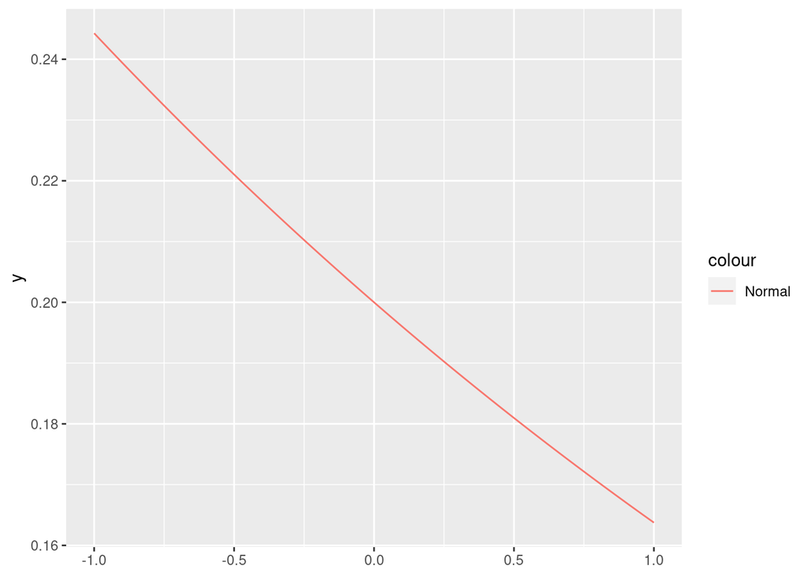

```r
ggplot() +
   xlim(-1, 1) +
   geom_function(
     aes(color = "Normal"),
     fun =~ 1/5 * exp(-.x/5)
     )
```

### c)

$$P(X\leq 5) = \int_0^5 \dfrac{1}{5}e^{-x/5}\; dx = 1-\dfrac{1}{e}$$

```r
integrate(function(x) 1/5 * exp(-x/5), lower = 0, upper = 5)
```

```
## 0.6321206 with absolute error < 7e-15
```

$$P(0\leq X \leq 8) = \int_0^8 \dfrac{1}{5}e^{-x/5}\; dx = 1-\dfrac{1}{e^{8/5}}$$

```r
integrate(function(x) 1/5 * exp(-x/5), lower = 0, upper = 8)
```

```
## 0.7981035 with absolute error < 8.9e-15
```

### d)

La función de distribución acumulativa esta dado por
$$F(x) = \int_{\infty}^x f(t)\; dt = \int_{-\infty}^0 0\; dt + \dfrac{1}{5}\int_0^x e^{-t/5}\; dt = -e^{-x/5}-1$$

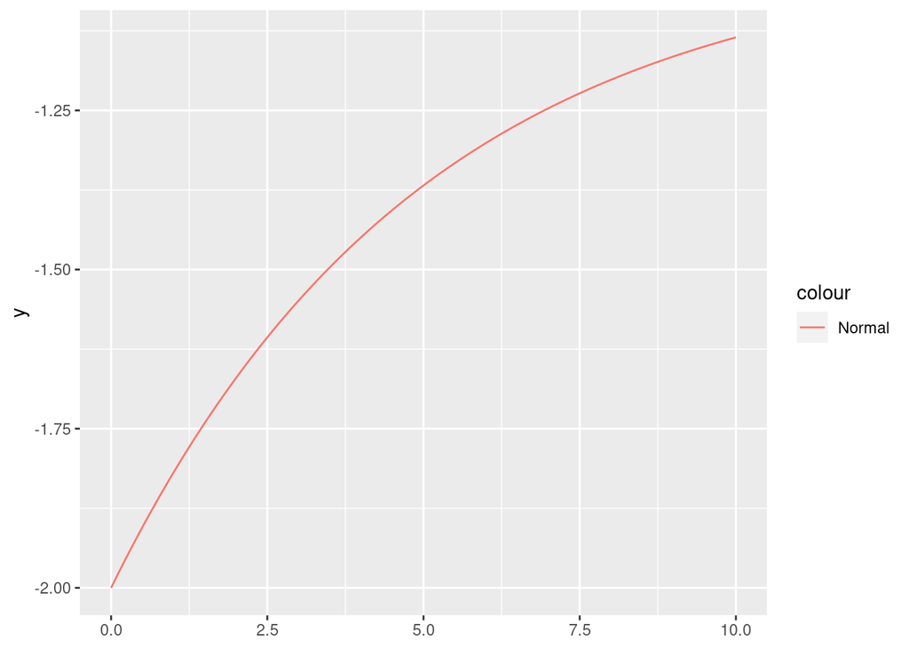

```r
ggplot() +
   xlim(0, 10) +
   geom_function(
     aes(color = "Normal"),
     fun =~ -exp(-.x/5) - 1
     )
```

# 3.5

$$F(x) = 1-exp(-x/100),\quad x>0$$

### a)

$$F^{'}(x) = 1-e^{-x/100} = \dfrac{1}{100}e^{-x/100}$$

### b)

$$1-(1-exp(-200/100)) = 0.13533$$

```r
1-(1-exp(-200/100))
```

```
## [1] 0.1353353
```

```r
integrate(function(x) 1/100 * exp(-x/100), lower = 0, upper = 200)
```

```
## 0.8646647 with absolute error < 9.6e-15
```

# 3.6

Función acumulada de v.a. es
$$F(X) = \left\{ \begin{array}{lr}
0&x<0\\
2x-x^2&0<x<1\\
1&x>1\\
\end{array}\right.$$

### a)

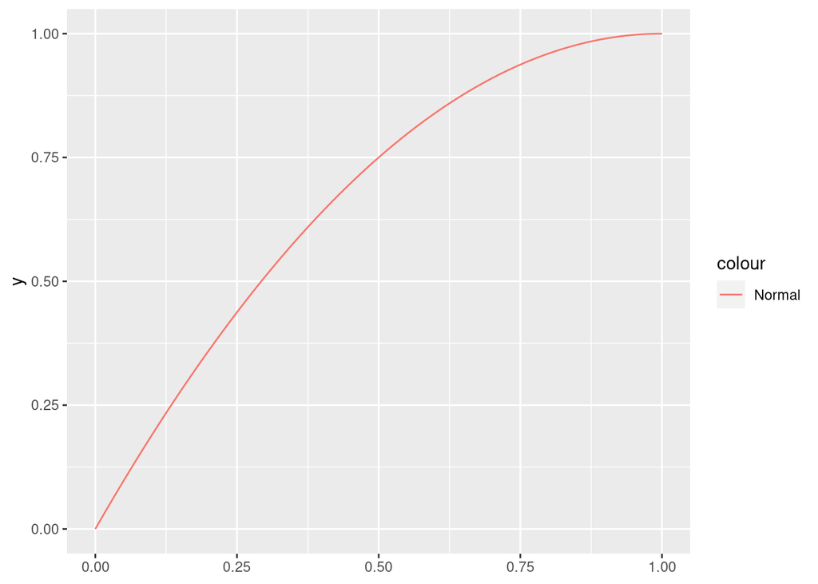

```r
# gráfico de F(x)
ggplot() +
   xlim(0, 1) +
   geom_function(
     aes(color = "Normal"),
     fun =~ 2*.x - .x^2,
     )
```

### b)

$P(X<1/2) = 2\cdot 1/2 - (1/2)^2 = 3/4 = 0.75$

```r
func <- function(x) 2*x - x^2
func(0.5)
```

```
## [1] 0.75
```

$1 - P(X>3/4) = 1 - ( 2\cdot 3/4 - (3/4)^2 ) = 1 - (-3/4) 1 - (15/16) = 1/16 = 0.0625$

```r
1-func(3/4)
```

```
## [1] 0.0625
```

### c)

$F^{'}(x) = 2 x - 2^2 = 2 - x$

# 3.7

```r
x <- c(0,1,2,3,4,5,6,7,8)
px <- c(0.05,0.1,0.1,0.1,0.2,0.25,0.1,0.05,0.05)
```

$E(X) = \sum\limits_{x=1}^n x\cdot p(x) = 0\cdot 0.05 + 1\cdot 0.1 + \ldots + 8\cdot 0.05 = 4$

```r
sum <- 0
for (i in 1:length(x)){
 sum <- sum + x[i]*px[i]
}
sum
```

```
## [1] 4
```

$E(X^2) = \sum\limits_{x=1}^n x^2p(x) = 0^2\cdot 0.05 + 1^2 \cdot 0.1 + \ldots + 8^2\cdot 0.05 = 20.1$

```r
sum2 <- 0
for (i in 1:length(x)){
 sum2 <- sum2 + x[i]^2 * px[i]
}
sum2
```

```
## [1] 20.1
```

$Var(X) = E(X^2) - E^2(X) = 20.1 - 4^2 = 4.1$

```r
sum2 - sum^2
```

```
## [1] 4.1
```

# 3.8

Calculamos el valor para un ganancia nula
$$E[X] = 0 = \dfrac{C\cdot 995}{1000} - \dfrac{50000\cdot 5}{100} \Longrightarrow 995C=250000 \Longrightarrow C = 251.26$$

# 3.9

Función de densidad de una v.a. X está dada por:
$$f(x) = \left\{\begin{array}{ll}
2(1-x) & 0<x<1 \\
0 & \mbox{para cualquier otro caso}
\end{array}\right.$$

### a)

$$E(X) = \int_0^1 x\cdot 2(1-x)\; dx = \int_0^1 2x-2x^2\; dx = \dfrac{1}{3}$$

```r
func <- function(x) x*2*(1-x)
integrate(func, lower = 0, upper = 1)
```

```
## 0.3333333 with absolute error < 3.7e-15
```

### b)

$$E(X^2) = \int_0^1 x^2\cdot 2(1-x)\; dx = \int_0^1 2x^2-2x^3\; dx = \dfrac{1}{6}$$

```r
func <- function(x) x^2*2*(1-x)
integrate(func, lower = 0, upper = 1)
```

```
## 0.1666667 with absolute error < 1.9e-15
```

$$Var(X) = E(X^2) - E(X)^2 = \dfrac{1}{6} - \left(\dfrac{1}{3}\right)^2 = \dfrac{1}{18}$$

```r
# varianza
1/6 - (1/3)^2
```

```
## [1] 0.05555556
```

# 3.10

Función de densidad de una v.a. de $X$ está dada por:
$$f(x) = \left\{\begin{array}{ll}
1/10&0<x<10\\
0&\mbox{para cualquier otro valor}\\
\end{array}\right.$$

### a)

$$E(X) = \int_0^{10} \dfrac{1}{10} x\cdot\; dx = \dfrac{1}{10}\int_0^{10} x\; dx = 5$$

```r
func <- function(x) 1/10 * x
integrate(func, lower = 0, upper = 10)
```

```
## 5 with absolute error < 5.6e-14
```

### b)

$$E(X) = \int_0^{10} \dfrac{1}{10} x^2 \cdot\; dx = \dfrac{1}{10}\int_0^{10} x^2 \; dx = \dfrac{100}{3}$$

```r
func <- function(x) 1/10 * x^2
integrate(func, lower = 0, upper = 10)
```

```
## 33.33333 with absolute error < 3.7e-13
```

$$Var(X) = E(X^2) - E(X)^2 = \dfrac{100}{3} - 5^2 = \dfrac{25}{3} = 8.33333$$

```r
# varianza
100/3 - 5^2
```

```
## [1] 8.333333
```

### c)

$\alpha_3$ también llamado coeficiente de asimetría estará dado por
$$\alpha_3 = \dfrac{\mu_3}{(\mu_2)^{3/2}}$$
de donde $\mu_3$ será:
$$\mu_3 = E(X-5)^3 = \int_0^{10} \dfrac{1}{10} \cdot (x-5)^3\; dx = \dfrac{1}{10}\cdot \int_0^{10}(x^3 - 15x^2 + 75x - 125)\; dx = 0$$

para $\mu_2$ tenemos
$$Var(X) = E(X-5)^2 = \int_0^{10} \dfrac{1}{10}\cdot (x-5)^2\; dx = \dfrac{1}{10}\int_0^{10} (x^2 - 10x + 25)\; dx = \dfrac{25}{3}$$

Entonces
$$\alpha_3 = \dfrac{\mu_3}{(\mu_2)^{3/2}} = \dfrac{0}{\left(\frac{25}{3}\right)^{3/2}} = 0$$

```r
func <- function(x) 1/10 * (x-5)^3
func2 <- function(x) 1/10 * (x-5)^2
integrate(func, lower = 0, upper = 10)
```

```
## 1.204593e-15 with absolute error < 3.5e-13
```

```r
integrate(func2, lower = 0, upper = 10)
```

```
## 8.333333 with absolute error < 9.3e-14
```

Donde nos menciona que se tiene un coeficiente de asimetría simétrica.

### d)

Para $\alpha_4$ como medida relativa de la curtosis tenemos
$$\alpha_4 = \dfrac{\mu_4}{\mu_2^2}$$

de donde tenemos $\mu_4$ de la siguiente manera
$$\mu_4 = E(X-5)^4 = \int_0^{10}\dfrac{1}{10}\cdot (x-5)^4\; dx = 125$$

```r
func4 <- function(x) 1/10 * (x-5)^4
integrate(func4, lower = 0, upper = 10)
```

```
## 125 with absolute error < 1.4e-12
```

# 3.11

La función de densidad viene dada por
$$f(x) = \left\{\begin{array}{ll}
\frac{1}{4}e^{-x/4}&x>0\\
0&\mbox{para cualquier otro valor}
\end{array}\right.$$

### a)

$$E(X) = \int_0^\infty x\cdot \dfrac{1}{4}e^{-x/4}\; dx = \dfrac{1}{4}\int_0^\infty x\cdot e^{-x/4}\; dx = 4$$

```r
func <- function(x) 1/4*x*exp(-x/4)
integrate(func, lower = 0, upper = Inf)
```

```
## 4 with absolute error < 1.2e-05
```

### b)

$$Var(X) = E(X-4)^2 = \int_0^\infty \dfrac{1}{4}e^{-x/4}\cdot (x-4)^2\; dx = \dfrac{1}{4}\int_0^\infty e^{-x/4}\cdot (x-4)^2\; dx = 16$$

```r
func <- function(x) 1/4*(x-4)^2*exp(-x/4)
integrate(func, lower = 0, upper = Inf)
```

```
## 16 with absolute error < 0.00051
```

### c)

$$\mu_3 = E(X-4)^3 = \dfrac{1}{4}\int_0^\infty (x-4)^3\cdot e^{-x/4}\; dx = 128$$

```r
func <- function(x) 1/4*(x-4)^3*exp(-x/4)
integrate(func, lower = 0, upper = Inf)
```

```
## 128 with absolute error < 0.00029
```

$$\alpha_3 = \dfrac{\mu_3}{\mu_2^{3/2}} = \dfrac{128}{16^{3/2}} = 2$$

```r
128/(16^(3/2))
```

```
## [1] 2
```

De donde podemos mencionar que se tiene una asimetría positiva.

### d)

$$\mu_4 = E(X-4)^4 = \dfrac{1}{4}\int_0^\infty (x-4)^4\cdot e^{-x/4}\; dx = 2304$$

```r
func <- function(x) 1/4*(x-4)^4*exp(-x/4)
integrate(func, lower = 0, upper = Inf)
```

```
## 2304 with absolute error < 0.0025
```

así,

$$\alpha_4 = \dfrac{\mu_4}{\mu^2_2} = \dfrac{2304}{16^2} = 9$$

```r
2304/16^2
```

```
## [1] 9
```

### e)

Del ejercico 3.10
$$V_X = \dfrac{E(X)}{Var(X)} = \dfrac{5}{8.33333}$$

```r
5/8.33333
```

```
## [1] 0.6000002
```

Del ejercio 3.11
$$V_Y = \dfrac{E(X)}{Var(X)} = \dfrac{4}{16}$$

```r
4/16
```

```
## [1] 0.25
```

# 3.12

Sea
$$E(X)=62.5,\qquad y \qquad \sqrt{Var(X)} = 10 \; \Rightarrow \; Var(X) = 100$$

y

$$E(aX+b) = 70 \qquad y \qquad Var(aX+b) = 80$$

entonces

$$a^2Var(X)=80 \; \Longrightarrow \; a=2\sqrt{\dfrac{1}{5}}$$

y

$$a E(X) + b = 70 \; \Longrightarrow \;b = 14.098$$

Entonces la respuesta estará dada por
$$aX+b = 2\sqrt{\dfrac{1}{5}} X + \left(70 - 125\sqrt{\dfrac{1}{5}}\right)$$

```r
EX <- function(x) 2*(1/5)^(1/2)*x + 70-125*(1/5)^(1/2)
EX(62.5)
```

```
## [1] 70
```

```r
VarX <- function(varx) (2*(1/5)^(1/2))^2 * varx
VarX(100)
```

```
## [1] 80
```

# 3.13

## a)

Sea $E(X)=\mu$ y $Var(X) = \sigma^2$ entonces,
$$E(X-c)^2 = E(X^2-2cX + c^2) = E(X^2) -2cE(X) + c^2 = E(X^2) - E^2(X) + E(X)\cdot E(X) - 2cE(X) +c^2 =$$
$$Var(X) + (E(X)-c)^2 = \sigma^2 + (\mu-c)^2$$

## b)

Cuando $c=\mu$

# 3.14

$$E(Y) = E\left(\dfrac{X-4}{4}\right)=\int_0^\infty \left(\dfrac{x-4}{4}\right)\cdot \dfrac{1}{4}\cdot e^{-x/4}\; dx = \dfrac{1}{16}\int_0^\infty (x-4)\cdot e^{-x/4} \; dx = 0$$

```r
fx = function(x) ((x-4)/4) * 1/4 * exp( -x/4 )
integrate(fx,lower = 0, upper = Inf)
```

```
## -5.632717e-13 with absolute error < 3e-06
```

$$Var(Y) = Var\left(\dfrac{X-4}{4}\right)^2 = \int_0^\infty \left(\dfrac{x-4}{4}\right)^2\cdot \dfrac{1}{4}\cdot e^{-x/4}\; dx = \dfrac{1}{64}\int_0^\infty (x-4)^2\cdot e^{-x/4}\; dx = 1$$

```r
fx = function(x) 1/64 * (x-4)^2 * exp(-x/4)
integrate(fx,lower = 0, upper = Inf)
```

```
## 1 with absolute error < 3.2e-05
```

## 3.15

$$E\bigg|X-\frac{1}{3}\bigg| = \int_0^1 \bigg|x-\dfrac{1}{3}\bigg|\cdot 2(1-x)\; \; dx = \int_0^{1/3}\left(\dfrac{1}{3}-x\right)*2(1-x)\; dx + \int_{1/3}^1\left(x-\dfrac{1}{3}\right)*2(1-x)\; dx = 0.1975309$$

```r
f <- function(x) abs(x-1/3)*2*(1-x)
integrate(f,lower = 0,upper = 1)
```

```
## 0.1975309 with absolute error < 5e-06
```

La desviación estandar del ejercicio 3.9 viene dada por $\sqrt{\dfrac{1}{18}} = 0.2357$

Luego comparando con la desviación media vemos que se tiene poca diferencia.

## 3.16

$$E|X-\mu|= \int_0^{10} |x-5|\cdot \dfrac{1}{10}\; dx = \dfrac{1}{10}\left[\int_0^5 (5-x)\; dx + \int_5^{10} (x-5)\; dx \right] = \dfrac{1}{10}\left(5x\bigg|_0^5 - \dfrac{x^2}{2}\bigg|_0^5 + \dfrac{x^2}{2}\bigg|_5^{10} - 5x\bigg|_5^{10}\right) =$$
$$\dfrac{1}{10}\left(25 - \dfrac{25}{2} + \dfrac{75}{2} - 25\right) = \dfrac{5}{2}$$

```r
f <- function(x) abs(x-5)*1/10
integrate(f,lower = 0,upper = 10)
```

```
## 2.5 with absolute error < 2.8e-14
```

```r
# desviación típica del ejercicio 10
(25/3)^(1/2)
```

```
## [1] 2.886751
```

# 3.17

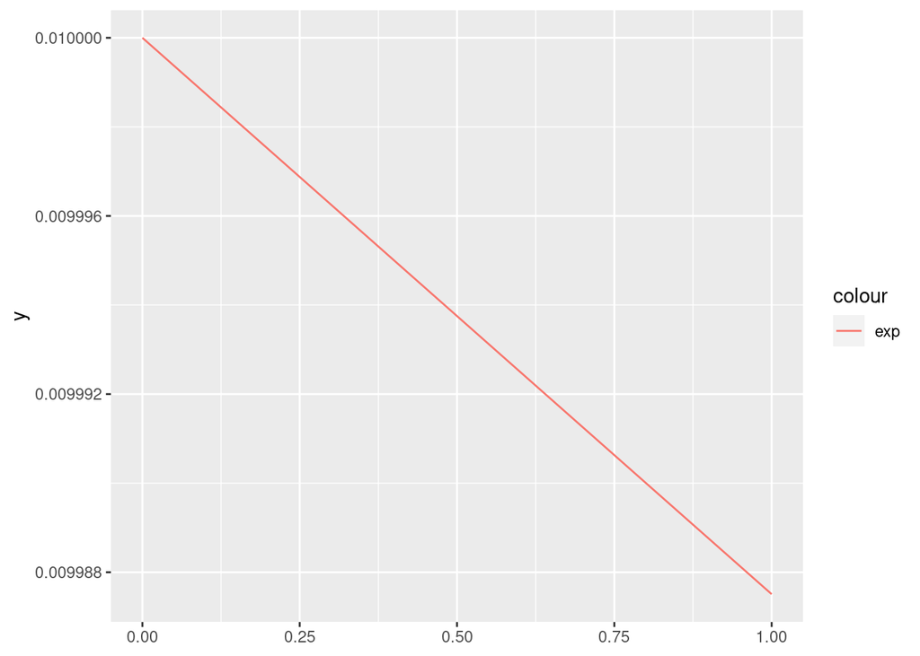

```r
ggplot() +
   xlim(0, 1) +
   geom_function(
     aes(color = "exp"),
     fun =~ 1/100*exp(-.x/800)
     )
```

## a)

La media es:

$$E(X) = \int_0^\infty x\cdot \dfrac{1}{800}\cdot e^{-x/800}\; dx = \dfrac{1}{800}\int_0^\infty x\cdot e^{-x/800} = 800$$

```r
integrate(function(x) 1/800*x*exp(-x/800), lower = 0, upper = Inf)
```

```
## 800 with absolute error < 0.034
```

La mediana es:

$$F(x_{0.5}) = P(X\leq x_{0.5}) = \dfrac{1}{800}\int_0^{x_{0.5}} e^{(-x/800)}\; dx = 0.5 \; \Longrightarrow \; -e^{-x_{0.5}/800}+1 = 0.5 \Longrightarrow x_{0.5} = 554.5177$$

```r
-800*log(0.5)
```

```
## [1] 554.5177
```

## b)

Recorrido intercuartil
$$F(x_{0.25}) = P(X\leq x_{0.25}) = \dfrac{1}{800}\int_0^{x_{0.25}} e^{(-x/800)}\; dx = 0.25 \; \Longrightarrow \; -e^{-x_{0.25}/800}+1 = 0.25 \Longrightarrow x_{0.25}$$
$$\Longrightarrow x_{0.25} = -800\cdot ln(0.25) = 1109.03548$$

$$F(x_{0.75}) = -800\cdot ln(0.75) = 230.14565$$

por lo que
$$x_{0.75} - x_{0.25} = |230.14565 - 1109.03548| = 878.8898$$

## c)

Recorrido interdecil

$$F(x_{0.1}) = P(X\leq x_{0.1}) = \dfrac{1}{800}\int_0^{x_{0.1}} e^{(-x/800)}\; dx = 0.1 \; \Longrightarrow \; -e^{-x_{0.1}/800}+1 = 0.1$$
$$\Longrightarrow x_{0.1} \Longrightarrow x_{0.1} = -800\cdot ln(0.1) = 1842.068$$

$$F(x_{0.9}) = -800\cdot ln(0.9) = 84.2884$$

$$x_{0.9}-x_{0.1} = |84.2884 - 1842.068| = 1757.78$$

## d)

```r
integrate(function(x) 1/800*exp(-x/800), lower = 0, upper = 800)
```

```
## 0.6321206 with absolute error < 7e-15
```

```r
1 - 0.6321206
```

```
## [1] 0.3678794
```

# 3.18

$$\begin{array}{rcl}
\dfrac{d^r m_{X-\mu}(t)}{dt^r}\bigg|_{t=\mu}&=&\dfrac{d^r}{dt^r}E[e^{t(X-\mu)}]\bigg|_{t=0}\\\\
&=&E\left\{ \dfrac{d^r}{dt^r}\left[e^{t(X-\mu)}\right] \right\}\\\\
&=&E\left[(X-\mu)^r e^{t(X-\mu)}\right]\bigg|_{t=0}\\\\
&=&E[X-\mu]^r\\\\
&=&u_r\\\\
\end{array}$$

# 3.19

## a)

$$m_X(t) = E\left[e^{tX}\right] = \int_{0}^{\infty} e^{tx}\cdot \dfrac{1}{16}\cdot x \cdot e^{-\frac{x}{4}}\; dx = \dfrac{1}{16}\int_0^\infty x\cdot e^{\frac{x(4t-1)}{4}}\; dx = (1-4t)^{-2}$$

## b)

$$\dfrac{dm_x(t)}{dt}\bigg|_{t=0} = \dfrac{d}{dt}\cdot (1-4t)^{-2}\bigg|_{t=0} = \dfrac{8}{(1-4x)^3}\bigg|_{t=0} = 8 = E(X)$$

$$\dfrac{d^2m_X(t)}{dt^2} \bigg|_{t=0} = \dfrac{d^2}{dt^2}(1-4x)^{-2} = \dfrac{d}{dt} \dfrac{8}{(1-4x)^2}\bigg|_{t=0} = \dfrac{96}{(-4x+1)^4}\bigg|_{t=0} = 96 = E(X^2)$$

$$Var(X) = E(X^2) - E^2(X) = 96 - 8^2 = 32$$

# 3.20

$$m_X(t) = \dfrac{1}{4}\int_0^{\infty} e^{tx}\cdot e^{-\frac{x}{4}}\; dx$$

# 3.21

$E(c) = \sum\limits_x c\cdot p(x) = c\sum\limits_x p(x) = c$

$E(cX+b) = \sum\limits_x (cx + b)p(x) = c\sum\limits_x x\cdot p(x) + b\sum\limits_x p(x) = cE(x) + b$

$E[g(X)+h(X)] = \sum\limits_x [g(x)+h(x)] p(x) + \sum\limits_x g(x)p(x) + \sum\limits_xh(x)p(x) = E[g(X)]+E[h(X)]$

# 3.22

$$Var(X)=(X-\mu)^2 = \sum_x (x-\mu)^2 p(x) = \sum_x x^2p(x) - 2\mu\sum_x x p(x) + \mu^2\sum_x p(x) =$$
$$E(X^2) - 2E^2(X) + E^2(X) = E(X^2) - E^2(X)$$